# Mini-project 6 - {ggplot2} extensions

## 8. Using `{cowplot}`

The `{cowplot}` package from Claus O. Wilke (hence COW) has a number of very useful additional functions that work on `{ggplot2}` plot objects. Claus’ book “[Fundamentals of Data Visualization](https://clauswilke.com/dataviz/)” is a really excellent book about creating high quality data visualizations and I heartily recommend that you read it. The package turns recommendations from the book into functions that you can apply in R.

In the code below we are going to add a watermark to the plot we created above.

[figure not shown]

```r
library(cowplot)
ggdraw(p2b) +
  draw_label("DRAFT", color = "grey", alpha=0.3, size = 100, angle = 45)
```

## 9. Challenge

Using what you’ve learned in this Mini Project 6, please try to create a graph similar to the one attached. Red points show ALT values that are outside the range i.e. where OUTRANGT is “High” or “Low”. You may need to refer back to Mini Project 5 to complete this challenge.

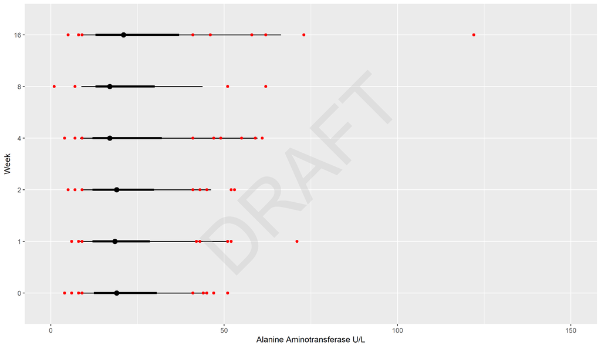

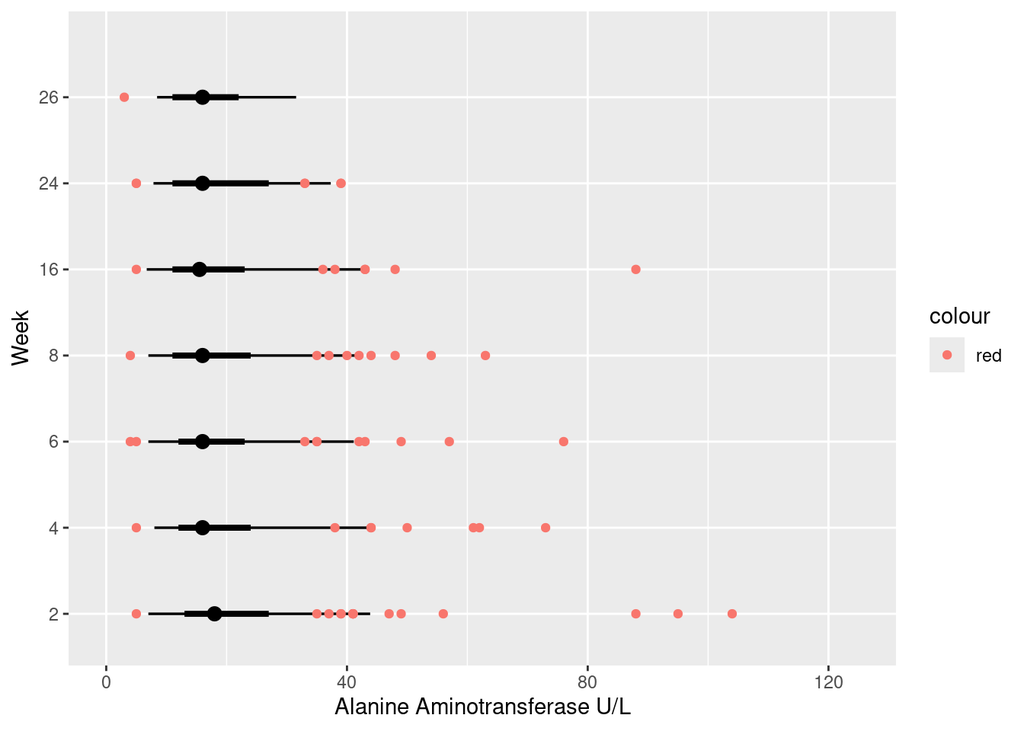